# Capstone Project Milestone Report

Bernard Fraenkel

December 29, 2015

# Synopsis

### Objective

This progress report demonstrates basic handling of the data for this project as well as the early implementation of a word prediction algorithm

### Findings

The complexity of the task is driven by a multiplicity of elements

- Large size of data sets
- Statistical properties characterized by a “long tail”
- Complexity of the algorithms, not only to compute a model, and implement it, but also in the details involved in cleaning the data (i.e. extracting words from text)
- Complexity of the overall task itself: a proper prediction algorithm requires additional intelligence beyond the scope of this project, such as: understanding context and basic grammar

# Data

### Large Data Set

To state the obvious, the data sets that we manipulated were very large. As the 2nd column of the Unix “wc” command shows, each source file contains 30-40 Million words (The first column shows number of lines/sentences, the third column indicates the number of characters in the file)

```
wc en_US/*.txt
  899288 37334690 210160014 en_US/en_US.blogs.txt
 1010242 34372720 205811889 en_US/en_US.news.txt
 2360148 30374206 167105338 en_US/en_US.twitter.txt
```

### Long Tails

As the two figures below show, it only takes a couple thousand single words to cover 90%, or more, of the number of instances in each data source. However, with 10,000 bigrams we only cover 55-65% of bigrams occurences in each data source. Furthermore, as the section below shows, these “core” sets are distinct enough that a single set cannot be used for the 3 use cases.

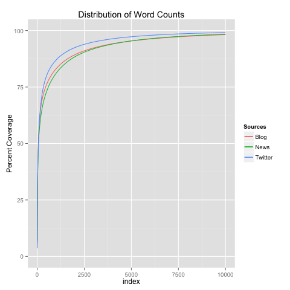

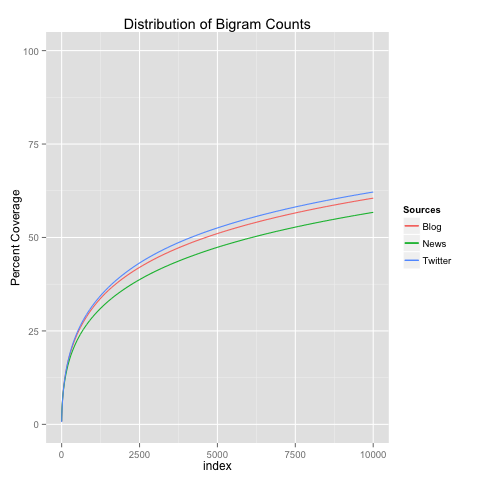

### Diverse Dictionary’s

The following shows the maximum index of the top 100 words in the News data source. This shows that one of the top 100 words in News (“county”, #100) is actually the 1513th most frequent in the Blogs, and another word (“percent”, #94) is the 2223th most frequent in the Twitter data source

```
[1] "Index of the top 100 News words, in other sources"
   News    Blog Twitter
    100    1513    2223
```

# Processing Pipeline

The data is processed according to the processing pipeline:

- The original source data is “tokenized” and stored in tokenized form, to be used by the following stages in the pipeline
- N-gram modeling
- Prediction using Markov model with backoff

# Findings

Natural Language Processing (NLP) is an immensily vast and complex problem set - even when limiting oneself to “next word prediction”. The following are ideas that jumped out by simply dealing with the data:

- Each of the data sets contains 30-40 Million words. As a consequence, writing efficient code is critical to not only experiment, but simply to process the data in a timely manner: i.e 2-3 hours per processing step
- Current implementation uses a simple tokenizer, which breaks up content based on punctuation. Further improvements would include:
  - Handling single apostrophies: e.g I’m, I’d, my friend’s, etc
  - Handling “start of sentence”, and “end of sentence” tokens
  - Noun plural and verb conjugations
  - Finding a better dictionary list than the Unix dict: e.g. “academia” is not in it
- Finding a way to accelerate the modeling which currently takes several hours
- Implement more sophisticated prediction algorithm such as Kneser-Ney

### Code Example

The following code snipet:

- First uses Run-length Encoding (RLE) to aggregate counts of tokens in the input vector of tokens `tokenSet`. This mininizes the number of lookups in the aggregate array
- Second, we use a hash table `hashTable` to accelerate the lookup of grams (words) in an array `gramCount`
- In the case of single words, we can pre-populate the hash table `hashTable` because the set of high-probability tokens is relatively small (a few thousand). However the code for n-grams (n>1) is more complicated and thus much slower because the hash table has to be created dynamically.

```r
# Assume tokenSet is large, and thus contains repeats
# Use Run Length Encoding to count the repeats inside tokenSet
countGramHash <- function(tokenSet, gramCount, hashTable) {

    # Sort orders all the tokens, and thus the repeats are one after the other
    # RLE then counts them
    tokenRLE <- rle(sort(tokenSet))
    # tokenRLE has 2 columns: values (i.e. the words) and lengths (i.e. counts)
    for (i in 1:length(tokenRLE$values)) {  # weird way to get the size of RLE
        token <- tokenRLE$values[i]
        count <- tokenRLE$lengths[i]
        # For each token, increment the gramCount for its hash value
        gramCount[hashTable[[token]]] <- gramCount[hashTable[[token]]] + count
    }
    gramCount  # return gramCount
}
```

# Plans for Shiny App

- Implement the Shiny App framework (ui.R and server.R)
- Improve the sophistication of the tokenization
  - for example, by replacing plural nouns to singular: See [A List of 100 Irregular Plural Nouns in English](http://grammar.about.com/od/words/a/A-List-Of-Irregular-Plural-Nouns-In-English.htm)
  - Handling single-apostrophy: I’m, I’d, my friend’s
  - Eliminating articles (a, an, the) in the modeling, but including them in the prediction
  - Find a more comprehensive dictionary
- Improve computational performance - mostly in the modeling section
- Improve the prediction algorithm by implementing Kneser-Ney